# Lab4 - HW

Sara Troshani

2026-10-09

## Data and Sample

The analysis uses the Household Pulse data. I focus on people ages 25 to 55 who have a non-missing work status.

```r
library(tidyverse)
library(AER)
load("~/Desktop/R Studio Data/Household Data/d_HHP2020_241.Rdata")

prime_age_laborforce_data <- d_HHP2020_24 %>%
  filter(
    !is.na(work_kind),
    Age >= 25,
    Age <= 55
  )

summary(prime_age_laborforce_data)
```

```
##       Age           Gender              Education           Mar_Stat
##  Min.   :25.00   male  :166600   lt hs       :  1494   Married  :232424
##  1st Qu.:34.00   female:221034   some hs     :  3423   widowed  :  3235
##  Median :41.00   trans :   948   high school : 33404   divorced : 45270
##  Mean   :40.97   other :  2358   some college: 69055   separated:  7012
##  3rd Qu.:48.00                   assoc deg   : 38251   never    :102090
##  Max.   :55.00                   college grad:130358   NAs      :   909
##                                  adv degree  :114955
##  income_midpoint     Race                Hispanic      Number_people_HH
##  Min.   : 12500   white:313601   not Hispanic:352603   Min.   : 1.000
##  1st Qu.: 62500   Black: 31005   Hispanic    : 38337   1st Qu.: 2.000
##  Median : 82500   Asian: 25157                         Median : 3.000
##  Mean   :112008   other: 21177                         Mean   : 3.093
##  3rd Qu.:175000                                        3rd Qu.: 4.000
##  Max.   :225000                                        Max.   :10.000
##  NAs    :62108
##  Number_kids_HH   Number_adults_HH                    private_health_ins
##  Min.   :0.0000   Min.   : 1.00    0                           : 29411
##  1st Qu.:0.0000   1st Qu.: 2.00    has private health insurance:285569
##  Median :1.0000   Median : 2.00    no private health insurance : 31798
##  Mean   :0.9724   Mean   : 2.12    NAs                         : 44162
##  3rd Qu.:2.0000   3rd Qu.: 2.00
##  Max.   :5.0000   Max.   :10.00
##
##                    public_health_ins                             work_kind
##  0                          : 29411   employed by govt                : 69228
##  has public health insurance: 38139   employed by private co          :226570
##  no public health insurance :256489   employed by nonprofit or charity: 51897
##  NAs                        : 66901   self employed                   : 36256
##                                       work for family business        :  6989
##
##
##                               workloss      income_midpoint_factor
##  yes recent household loss of work: 60938   125000 :71817
##  no                               :329762   62500  :52135
##  NAs                              :   240   225000 :51766
##                                             82500  :48997
##                                             175000 :39806
##                                             (Other):64311
##                                             NAs    :62108
```

[output cut: 9 more lines]

```
##  Min.   :1.000   Min.   :1.00    Min.   :1.000   Min.   :1.000
##  1st Qu.:1.000   1st Qu.:1.00    1st Qu.:1.000   1st Qu.:1.000
##  Median :1.000   Median :2.00    Median :2.000   Median :1.000
##  Mean   :1.681   Mean   :2.04    Mean   :1.792   Mean   :1.681
##  3rd Qu.:2.000   3rd Qu.:3.00    3rd Qu.:2.000   3rd Qu.:2.000
##  Max.   :4.000   Max.   :4.00    Max.   :4.000   Max.   :4.000
##  NAs    :34462   NAs    :34176   NAs    :34511   NAs    :34666
##       YEAR         Begin_Date             K4SUM
##  Min.   :20.00   Min.   :2020-04-23   Min.   : 4.000
##  1st Qu.:20.00   1st Qu.:2020-12-09   1st Qu.: 4.000
##  Median :22.00   Median :2022-04-27   Median : 6.000
##  Mean   :21.73   Mean   :2022-05-05   Mean   : 7.194
##  3rd Qu.:23.00   3rd Qu.:2023-08-23   3rd Qu.: 9.000
##  Max.   :24.00   Max.   :2024-07-23   Max.   :16.000
##                                       NAs    :35439
```

This sample includes people between ages 25 and 55 who have information about their work status. I use this group because it focuses on people who are more likely to be in the labor force.

## Main Regression

The main regression looks at how income is related to age, gender, education, race, and Hispanic status.

```r
model_1 <- lm(
  income_midpoint ~ Age + Gender + Education + Race + Hispanic,
  data = prime_age_laborforce_data
)

summary(model_1)
```

```
##
## Call:
## lm(formula = income_midpoint ~ Age + Gender + Education + Race +
##     Hispanic, data = prime_age_laborforce_data)
##
## Residuals:
##     Min      1Q  Median      3Q     Max
## -169354  -43494   -8346   43393  220845
##
## Coefficients:
##                       Estimate Std. Error t value Pr(>|t|)
## (Intercept)            15722.1     1876.8   8.377   <2e-16 ***
## Age                     1238.5       12.4  99.888   <2e-16 ***
## Genderfemale          -19090.8      206.8 -92.321   <2e-16 ***
## Gendertrans           -37681.6     2008.4 -18.762   <2e-16 ***
## Genderother           -28502.7     1303.0 -21.875   <2e-16 ***
## Educationsome hs         133.0     2138.3   0.062     0.95
## Educationhigh school   15108.2     1827.9   8.265   <2e-16 ***
## Educationsome college  29587.9     1809.3  16.354   <2e-16 ***
## Educationassoc deg     33016.9     1822.6  18.115   <2e-16 ***
## Educationcollege grad  67093.1     1802.0  37.232   <2e-16 ***
## Educationadv degree    88508.4     1802.9  49.091   <2e-16 ***
## RaceBlack             -24763.6      395.1 -62.674   <2e-16 ***
## RaceAsian               9508.4      426.3  22.305   <2e-16 ***
## Raceother              -8681.5      454.5 -19.101   <2e-16 ***
## HispanicHispanic       -9788.5      354.6 -27.606   <2e-16 ***
## ---
## Signif. codes:  0 '***' 0.001 '**' 0.01 '*' 0.05 '.' 0.1 ' ' 1
##
## Residual standard error: 58110 on 328817 degrees of freedom
##   (62108 observations deleted due to missingness)
## Multiple R-squared:  0.2289, Adjusted R-squared:  0.2288
## F-statistic:  6970 on 14 and 328817 DF,  p-value: < 2.2e-16
```

```r
confint(model_1)
```

```
##                            2.5 %     97.5 %
## (Intercept)            12043.663  19400.549
## Age                     1214.152   1262.753
## Genderfemale          -19496.094 -18685.503
## Gendertrans           -41617.991 -33745.208
## Genderother           -31056.543 -25948.822
## Educationsome hs       -4057.955   4323.986
## Educationhigh school   11525.634  18690.829
## Educationsome college  26041.808  33134.032
## Educationassoc deg     29444.666  36589.148
## Educationcollege grad  63561.211  70625.072
## Educationadv degree    84974.668  92042.071
## RaceBlack             -25537.982 -23989.150
## RaceAsian               8672.843  10343.867
## Raceother              -9572.310  -7790.666
## HispanicHispanic      -10483.516  -9093.583
```

The results show that education has a strong relationship with income. College graduates are predicted to have about $67,093 higher income than the less-than-high-school group, holding the other variables constant.

People with an advanced degree are predicted to have about $88,508 higher income than the less-than-high-school group.

Age also has a positive relationship with income. An additional year of age is associated with about $1,239 more in predicted income.

Most of the coefficients are statistically significant. The “some high school” category is not statistically significant.

## Predicted Values

I compare predicted income for a Hispanic Black female with an advanced degree and a Hispanic Black female with a high school education.

```r
to_be_predicted1 <- data.frame(
  Age = 25:55,
  Gender = "female",
  Education = "adv degree",
  Race = "Black",
  Hispanic = "Hispanic"
)

to_be_predicted1$yhat <- predict(
  model_1,
  newdata = to_be_predicted1
)

head(to_be_predicted1)
```

```
##   Age Gender  Education  Race Hispanic     yhat
## 1  25 female adv degree Black Hispanic 81548.88
## 2  26 female adv degree Black Hispanic 82787.34
## 3  27 female adv degree Black Hispanic 84025.79
## 4  28 female adv degree Black Hispanic 85264.24
## 5  29 female adv degree Black Hispanic 86502.69
## 6  30 female adv degree Black Hispanic 87741.15
```

```r
to_be_predicted2 <- data.frame(
  Age = 25:55,
  Gender = "female",
  Education = "high school",
  Race = "Black",
  Hispanic = "Hispanic"
)

to_be_predicted2$yhat <- predict(
  model_1,
  newdata = to_be_predicted2
)

head(to_be_predicted2)
```

```
##   Age Gender   Education  Race Hispanic      yhat
## 1  25 female high school Black Hispanic  8148.745
## 2  26 female high school Black Hispanic  9387.198
## 3  27 female high school Black Hispanic 10625.651
## 4  28 female high school Black Hispanic 11864.103
## 5  29 female high school Black Hispanic 13102.556
## 6  30 female high school Black Hispanic 14341.009
```

The predicted income is higher for the person with an advanced degree at every age.

For example, at age 25, the predicted income for the advanced degree group is about $81,549, compared with about $8,149 for the high school group.

The predicted income also increases with age for both groups.

## Predicted Income Graph

```r
comparison <- data.frame(
  Age = 25:55,
  Advanced_Degree = to_be_predicted1$yhat,
  High_School = to_be_predicted2$yhat
)

head(comparison)
```

```
##   Age Advanced_Degree High_School
## 1  25        81548.88    8148.745
## 2  26        82787.34    9387.198
## 3  27        84025.79   10625.651
## 4  28        85264.24   11864.103
## 5  29        86502.69   13102.556
## 6  30        87741.15   14341.009
```

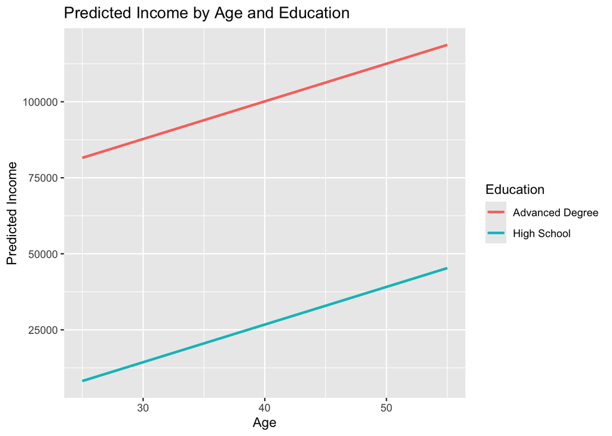

```r
ggplot(comparison, aes(x = Age)) +
  geom_line(aes(y = Advanced_Degree, color = "Advanced Degree"), linewidth = 1) +
  geom_line(aes(y = High_School, color = "High School"), linewidth = 1) +
  labs(
    title = "Predicted Income by Age and Education",
    x = "Age",
    y = "Predicted Income",
    color = "Education"
  )
```

The graph shows that predicted income increases with age for both education groups.

The advanced degree group has a much higher predicted income than the high school group at every age.

## Robust Standard Errors

```r
coeftest(model_1, vcovHC(model_1))
```

```
##
## t test of coefficients:
##
##                         Estimate Std. Error  t value Pr(>|t|)
## (Intercept)            15722.106   1561.843  10.0664   <2e-16 ***
## Age                     1238.453     12.213 101.4059   <2e-16 ***
## Genderfemale          -19090.798    208.363 -91.6229   <2e-16 ***
## Gendertrans           -37681.600   1925.652 -19.5682   <2e-16 ***
## Genderother           -28502.683   1288.222 -22.1256   <2e-16 ***
## Educationsome hs         133.016   1685.430   0.0789   0.9371
## Educationhigh school   15108.231   1487.188  10.1589   <2e-16 ***
## Educationsome college  29587.920   1476.537  20.0387   <2e-16 ***
## Educationassoc deg     33016.907   1488.038  22.1882   <2e-16 ***
## Educationcollege grad  67093.142   1473.118  45.5450   <2e-16 ***
## Educationadv degree    88508.370   1474.728  60.0167   <2e-16 ***
## RaceBlack             -24763.566    357.186 -69.3297   <2e-16 ***
## RaceAsian               9508.355    460.126  20.6647   <2e-16 ***
## Raceother              -8681.488    443.974 -19.5541   <2e-16 ***
## HispanicHispanic       -9788.550    340.988 -28.7065   <2e-16 ***
## ---
## Signif. codes:  0 '***' 0.001 '**' 0.01 '*' 0.05 '.' 0.1 ' ' 1
```

I also used robust standard errors to check the results.

The standard errors change a little, but the main results stay the same. Most of the variables are still statistically significant.

The “some high school” category is still not statistically significant.

## Log Income Model

```r
model_log <- lm(
  log(income_midpoint) ~ Age + Gender + Education + Race + Hispanic,
  data = prime_age_laborforce_data
)

summary(model_log)
```

```
##
## Call:
## lm(formula = log(income_midpoint) ~ Age + Gender + Education +
##     Race + Hispanic, data = prime_age_laborforce_data)
##
## Residuals:
##      Min       1Q   Median       3Q      Max
## -2.68130 -0.37895  0.08909  0.47499  2.44612
##
## Coefficients:
##                         Estimate Std. Error t value Pr(>|t|)
## (Intercept)           10.1243333  0.0209449 483.379   <2e-16 ***
## Age                    0.0133645  0.0001384  96.588   <2e-16 ***
## Genderfemale          -0.2102935  0.0023077 -91.125   <2e-16 ***
## Gendertrans           -0.4930750  0.0224137 -21.999   <2e-16 ***
## Genderother           -0.3504078  0.0145416 -24.097   <2e-16 ***
## Educationsome hs       0.0195068  0.0238632   0.817    0.414
## Educationhigh school   0.3476806  0.0203992  17.044   <2e-16 ***
## Educationsome college  0.5586726  0.0201914  27.669   <2e-16 ***
## Educationassoc deg     0.6317112  0.0203402  31.057   <2e-16 ***
## Educationcollege grad  0.9999762  0.0201107  49.724   <2e-16 ***
## Educationadv degree    1.1989682  0.0201208  59.589   <2e-16 ***
## RaceBlack             -0.3180581  0.0044095 -72.130   <2e-16 ***
## RaceAsian              0.0564373  0.0047574  11.863   <2e-16 ***
## Raceother             -0.1154108  0.0050723 -22.753   <2e-16 ***
## HispanicHispanic      -0.1192296  0.0039571 -30.130   <2e-16 ***
## ---
## Signif. codes:  0 '***' 0.001 '**' 0.01 '*' 0.05 '.' 0.1 ' ' 1
##
## Residual standard error: 0.6485 on 328817 degrees of freedom
##   (62108 observations deleted due to missingness)
## Multiple R-squared:  0.2349, Adjusted R-squared:  0.2349
## F-statistic:  7212 on 14 and 328817 DF,  p-value: < 2.2e-16
```

```r
pred_level <- predict(model_1)
pred_log <- exp(predict(model_log))

mean(pred_level)
```

```
## [1] 112008
```

```r
mean(pred_log)
```

```
## [1] 95028.4
```

I also estimated a model using the log of income instead of income in dollars.

The overall results are similar to the regular model. Education is still strongly related to income.

The average predicted income from the regular model is about $112,008.

The average predicted income after converting the log predictions back into dollars is about $95,028.

The two numbers are different because the models treat income differently.

## Female Only Model

```r
female_data <- prime_age_laborforce_data %>%
  filter(Gender == "female")

model_female <- lm(
  income_midpoint ~ Age + Education + Race + Hispanic,
  data = female_data
)

summary(model_female)
```

```
##
## Call:
## lm(formula = income_midpoint ~ Age + Education + Race + Hispanic,
##     data = female_data)
##
## Residuals:
##     Min      1Q  Median      3Q     Max
## -151798  -42735   -9150   39374  212510
##
## Coefficients:
##                        Estimate Std. Error t value Pr(>|t|)
## (Intercept)             -314.51    2551.34  -0.123    0.902
## Age                     1050.47      16.17  64.983  < 2e-16 ***
## Educationsome hs        4107.91    2890.62   1.421    0.155
## Educationhigh school   19557.65    2495.60   7.837 4.64e-15 ***
## Educationsome college  33064.52    2471.74  13.377  < 2e-16 ***
## Educationassoc deg     38686.12    2484.75  15.569  < 2e-16 ***
## Educationcollege grad  71054.59    2462.83  28.851  < 2e-16 ***
## Educationadv degree    93496.44    2463.14  37.958  < 2e-16 ***
## RaceBlack             -25746.09     469.94 -54.786  < 2e-16 ***
## RaceAsian              13339.91     614.55  21.707  < 2e-16 ***
## Raceother              -7978.85     584.63 -13.648  < 2e-16 ***
## HispanicHispanic       -8626.14     456.55 -18.894  < 2e-16 ***
## ---
## Signif. codes:  0 '***' 0.001 '**' 0.01 '*' 0.05 '.' 0.1 ' ' 1
##
## Residual standard error: 56980 on 186273 degrees of freedom
##   (34749 observations deleted due to missingness)
## Multiple R-squared:  0.2161, Adjusted R-squared:  0.2161
## F-statistic:  4669 on 11 and 186273 DF,  p-value: < 2.2e-16
```

I also ran the regression using only females.

Education still has a strong relationship with income.

For females, college graduates are predicted to have about $71,055 higher income than the less-than-high-school group.

Females with an advanced degree are predicted to have about $93,496 higher income than the less-than-high-school group.

This shows that the relationship between education and income is still strong even when I only look at females.

## Joint F Tests

```r
drop1(model_1, test = "F")
```

```
## Single term deletions
##
## Model:
## income_midpoint ~ Age + Gender + Education + Race + Hispanic
##           Df  Sum of Sq        RSS     AIC  F value    Pr(>F)
## <none>                  1.1104e+15 7214660
## Age        1 3.3693e+13 1.1441e+15 7224488  9977.68 < 2.2e-16 ***
## Gender     3 2.9995e+13 1.1404e+15 7223419  2960.83 < 2.2e-16 ***
## Education  6 2.2108e+14 1.3315e+15 7274357 10911.65 < 2.2e-16 ***
## Race       3 1.6534e+13 1.1269e+15 7219515  1632.12 < 2.2e-16 ***
## Hispanic   1 2.5735e+12 1.1129e+15 7215420   762.09 < 2.2e-16 ***
## ---
## Signif. codes:  0 '***' 0.001 '**' 0.01 '*' 0.05 '.' 0.1 ' ' 1
```

```r
drop1(model_female, test = "F")
```

```
## Single term deletions
##
## Model:
## income_midpoint ~ Age + Education + Race + Hispanic
##           Df  Sum of Sq        RSS     AIC F value    Pr(>F)
## <none>                  6.0474e+14 4079812
## Age        1 1.3709e+13 6.1845e+14 4083986 4222.80 < 2.2e-16 ***
## Education  6 1.2889e+14 7.3363e+14 4115792 6616.99 < 2.2e-16 ***
## Race       3 1.2254e+13 6.1699e+14 4083543 1258.15 < 2.2e-16 ***
## Hispanic   1 1.1590e+12 6.0590e+14 4080167  356.99 < 2.2e-16 ***
## ---
## Signif. codes:  0 '***' 0.001 '**' 0.01 '*' 0.05 '.' 0.1 ' ' 1
```

The F-tests show whether groups of variables are statistically significant together.

In the main model, age, gender, education, race, and Hispanic status are statistically significant.

Education is also jointly significant in the female-only model.

This means the education variables are important in explaining differences in predicted income.

## Conclusion

Overall, the results show a strong relationship between education and income.

People with higher levels of education tend to have higher predicted income, even after controlling for age, gender, race, and Hispanic status.

The results are also similar when I use robust standard errors, a log income model, and a female-only sample.

These results show an association between education and income, but they do not prove that education directly causes the differences in income.